# WeRateDogs

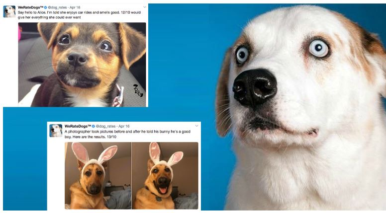

WeRateDogs is a Twitter account that rates people's dogs with a humorous comment about the dog. The account was started in 2015 by college student Matt Nelson, and has received international media attention both for its popularity and for the attention drawn to social media.

These ratings almost always have a denominator of 10. The numerators, though? Almost always greater than 10. 11/10, 12/10, 13/10, etc. Why? Because ["they're good dogs Brent"](https://knowyourmeme.com/memes/theyre-good-dogs-brent) This describes the insights from the WeRateDog twitter archive.

WeRateDogs asks people to send photos of their dogs, then tweets selected photos rating and a humorous comment. Dogs are rated on a scale of one to ten, but are invariably given ratings in excess of the maximum, such as "13/10". Popular posts are re-posted on Instagram and Facebook.

The tweets looked into are from year 2017.They describe dog ratings, name of dogs, text of each tweets dog stages and most like tweets.

A couple of insights were looked into these tweets over this period, such Liked tweets or favorite counts compared to their ratings also images uploaded in relation to their favorite counts.

Statsitics show that all tweets have an average of 8907 likes on twitter. Total number of images uploaded were 2387. The bar chart below shows that tweets with image uploads of four had the highest likes with tweets having just one image of the dog having the least favorite counts.

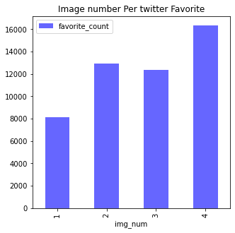

The image below describes stages of dogs compared to their twitter likes. As shown in the wrangle_act visualizations highest ratings were puppo had the most favorite likes with pupper as the lowest.

[figure not shown]